# case_study_divvy_bike_trip

Aidan Kao

10/26/2022

## Load packages

```r
library(tidyverse)
library(lubridate)
```

## Load datasets

```r
df_202110 <- read_csv('dataset/202110-tripdata.csv')
df_202111 <- read_csv('dataset/202111-tripdata.csv')
df_202112 <- read_csv('dataset/202112-tripdata.csv')
df_202201 <- read_csv('dataset/202201-tripdata.csv')
df_202202 <- read_csv('dataset/202202-tripdata.csv')
df_202203 <- read_csv('dataset/202203-tripdata.csv')
df_202204 <- read_csv('dataset/202204-tripdata.csv')
df_202205 <- read_csv('dataset/202205-tripdata.csv')
df_202206 <- read_csv('dataset/202206-tripdata.csv')
df_202207 <- read_csv('dataset/202207-tripdata.csv')
df_202208 <- read_csv('dataset/202208-tripdata.csv')
df_202209 <- read_csv('dataset/202209-tripdata.csv')
all_trips <- bind_rows(df_202110,df_202111,df_202112,df_202201,df_202202,df_202203,df_202204,df_202205,df_202206,df_202207,df_202208,df_202209)
```

```r
head(all_trips)
```

```
## # A tibble: 6 × 15
##   ride_id        ridea…¹ start…² ended…³ start…⁴ start…⁵ end_s…⁶ end_s…⁷ start…⁸
##   <chr>          <chr>   <chr>   <chr>   <chr>   <chr>   <chr>   <chr>     <dbl>
## 1 620BC6107255B… electr… 2021/1… 2021/1… Kingsb… KA1503… <NA>    <NA>       41.9
## 2 4471C70731AB2… electr… 2021/1… 2021/1… <NA>    <NA>    <NA>    <NA>       41.9
## 3 26CA69D43D15E… electr… 2021/1… 2021/1… <NA>    <NA>    <NA>    <NA>       41.9
## 4 362947F0437E1… electr… 2021/1… 2021/1… <NA>    <NA>    <NA>    <NA>       41.9
## 5 BB731DE2F2EC5… electr… 2021/1… 2021/1… <NA>    <NA>    <NA>    <NA>       41.9
## 6 7176307BBC097… electr… 2021/1… 2021/1… <NA>    <NA>    <NA>    <NA>       41.9
## # … with 6 more variables: start_lng <dbl>, end_lat <dbl>, end_lng <dbl>,
## #   member_casual <chr>, ride_length <time>, day_of_week <dbl>, and abbreviated
## #   variable names ¹rideable_type, ²started_at, ³ended_at, ⁴start_station_name,
## #   ⁵start_station_id, ⁶end_station_name, ⁷end_station_id, ⁸start_lat
```

```r
str(all_trips)
```

```
## spc_tbl_ [5,828,235 × 15] (S3: spec_tbl_df/tbl_df/tbl/data.frame)
##  $ ride_id           : chr [1:5828235] "620BC6107255BF4C" "4471C70731AB2E45" "26CA69D43D15EE14" "362947F0437E1514" ...
##  $ rideable_type     : chr [1:5828235] "electric_bike" "electric_bike" "electric_bike" "electric_bike" ...
##  $ started_at        : chr [1:5828235] "2021/10/22 12:46" "2021/10/21 09:12" "2021/10/16 16:28" "2021/10/16 16:17" ...
##  $ ended_at          : chr [1:5828235] "2021/10/22 12:49" "2021/10/21 09:14" "2021/10/16 16:36" "2021/10/16 16:19" ...
##  $ start_station_name: chr [1:5828235] "Kingsbury St & Kinzie St" NA NA NA ...
##  $ start_station_id  : chr [1:5828235] "KA1503000043" NA NA NA ...
##  $ end_station_name  : chr [1:5828235] NA NA NA NA ...
##  $ end_station_id    : chr [1:5828235] NA NA NA NA ...
##  $ start_lat         : num [1:5828235] 41.9 41.9 41.9 41.9 41.9 ...
##  $ start_lng         : num [1:5828235] -87.6 -87.7 -87.7 -87.7 -87.7 ...
##  $ end_lat           : num [1:5828235] 41.9 41.9 41.9 41.9 41.9 ...
##  $ end_lng           : num [1:5828235] -87.6 -87.7 -87.7 -87.7 -87.7 ...
##  $ member_casual     : chr [1:5828235] "member" "member" "member" "member" ...
##  $ ride_length       : 'hms' num [1:5828235] 00:03:08 00:01:37 00:07:47 00:01:15 ...
##   ..- attr(*, "units")= chr "secs"
##  $ day_of_week       : num [1:5828235] 6 5 7 7 4 5 5 4 5 4 ...
##  - attr(*, "spec")=
##   .. cols(
##   ..   ride_id = col_character(),
##   ..   rideable_type = col_character(),
##   ..   started_at = col_character(),
##   ..   ended_at = col_character(),
##   ..   start_station_name = col_character(),
##   ..   start_station_id = col_character(),
##   ..   end_station_name = col_character(),
##   ..   end_station_id = col_character(),
##   ..   start_lat = col_double(),
##   ..   start_lng = col_double(),
##   ..   end_lat = col_double(),
##   ..   end_lng = col_double(),
##   ..   member_casual = col_character(),
##   ..   ride_length = col_time(format = ""),
##   ..   day_of_week = col_double()
##   .. )
##  - attr(*, "problems")=<externalptr>
```

```r
print("List of column names:")
```

```
## [1] "List of column names:"
```

```r
colnames(all_trips)
```

```
##  [1] "ride_id"            "rideable_type"      "started_at"
##  [4] "ended_at"           "start_station_name" "start_station_id"
##  [7] "end_station_name"   "end_station_id"     "start_lat"
## [10] "start_lng"          "end_lat"            "end_lng"
## [13] "member_casual"      "ride_length"        "day_of_week"
```

```r
print("How many rows are in data frame?")
```

```
## [1] "How many rows are in data frame?"
```

```r
nrow(all_trips)
```

```
## [1] 5828235
```

```r
print("Dimensions of the data frame?")
```

```
## [1] "Dimensions of the data frame?"
```

```r
dim(all_trips)
```

```
## [1] 5828235      15
```

```r
print("Statistical summary of data.")
```

```
## [1] "Statistical summary of data."
```

```r
summary(all_trips)
```

```
##    ride_id          rideable_type       started_at          ended_at
##  Length:5828235     Length:5828235     Length:5828235     Length:5828235
##  Class :character   Class :character   Class :character   Class :character
##  Mode  :character   Mode  :character   Mode  :character   Mode  :character
##
##
##
##
##  start_station_name start_station_id   end_station_name   end_station_id
##  Length:5828235     Length:5828235     Length:5828235     Length:5828235
##  Class :character   Class :character   Class :character   Class :character
##  Mode  :character   Mode  :character   Mode  :character   Mode  :character
##
##
##
##
##    start_lat       start_lng         end_lat         end_lng
##  Min.   :41.64   Min.   :-87.84   Min.   :41.39   Min.   :-88.97
##  1st Qu.:41.88   1st Qu.:-87.66   1st Qu.:41.88   1st Qu.:-87.66
##  Median :41.90   Median :-87.64   Median :41.90   Median :-87.64
##  Mean   :41.90   Mean   :-87.65   Mean   :41.90   Mean   :-87.65
##  3rd Qu.:41.93   3rd Qu.:-87.63   3rd Qu.:41.93   3rd Qu.:-87.63
##  Max.   :45.64   Max.   :-73.80   Max.   :42.37   Max.   :-87.30
##                                   NA's   :5844    NA's   :5844
##  member_casual      ride_length        day_of_week
##  Length:5828235     Length:5828235    Min.   :1.000
##  Class :character   Class1:hms        1st Qu.:2.000
##  Mode  :character   Class2:difftime   Median :4.000
##                     Mode  :numeric    Mean   :4.117
##                                       3rd Qu.:6.000
##                                       Max.   :7.000
##
```

#### 小結：

- 自2021/10到2022/9共12個月的資料共5,828,235筆，共15個column，其中包含新增的ride_length(騎乘時間)與day_of_week(星期幾)
- Column中包含部分應可以清除的feature，如ride_id

```r
# 檢查class unique value
print("Unique key (member_casual):")
```

```
## [1] "Unique key (member_casual):"
```

```r
unique(as.vector(as.matrix(all_trips$member_casual)))
```

```
## [1] "member" "casual"
```

```r
print("-----------------------------------------------")
```

```
## [1] "-----------------------------------------------"
```

```r
print("Unique key (rideable_type):")
```

```
## [1] "Unique key (rideable_type):"
```

```r
unique(as.vector(as.matrix(all_trips$rideable_type)))
```

```
## [1] "electric_bike" "docked_bike"   "classic_bike"
```

```r
print("-----------------------------------------------")
```

```
## [1] "-----------------------------------------------"
```

```r
print("Amount of unique key (start_station_name):")
```

```
## [1] "Amount of unique key (start_station_name):"
```

```r
length(unique(as.vector(as.matrix(all_trips$start_station_name))))
```

```
## [1] 1592
```

```r
print("-----------------------------------------------")
```

```
## [1] "-----------------------------------------------"
```

```r
print("Amount of unique key (end_station_name):")
```

```
## [1] "Amount of unique key (end_station_name):"
```

```r
length(unique(as.vector(as.matrix(all_trips$end_station_name))))
```

```
## [1] 1610
```

#### 小結：

- 主要乘客分類為member(會員)與casual(休閒，意指分散客戶)，此特徵由於切合分析的題目：「比較會員與一般用戶的差異？」，後續可著重分析
- bike的類別包含電動車、dock租借車(如同youbike)，以及一般車
- 站名數量共約1600上下，包含起始與抵達站

## Data Processing

```r
# drop ride id
all_trips$ride_id <- NULL
```

#### 小結：

- 因為ride_id為用戶個人編號，無直接與分析問題相關，故暫時刪除

## Data Analysis

### Calculate the mean and the max of ride_length

```r
all_trips %>% summarize(mean_ride_len=seconds_to_period(mean(as.difftime(ride_length, format="%H:%M:%S", units="minutes"), na.rm=TRUE)), max_ride_len=seconds_to_period(max(as.difftime(ride_length, format="%H:%M:%S", units="minutes"), na.rm=TRUE)))
```

```
## # A tibble: 1 × 2
##   mean_ride_len         max_ride_len
##   <Period>              <Period>
## 1 16M 46.7761193281985S 23H 59M 57S
```

#### 小結:

- 平均騎乘時間為16分46秒，但最大騎乘時間為23小時59分，後續可比較box-whisker plot確認是否為outlier

### Calculate the mode of day_of_week

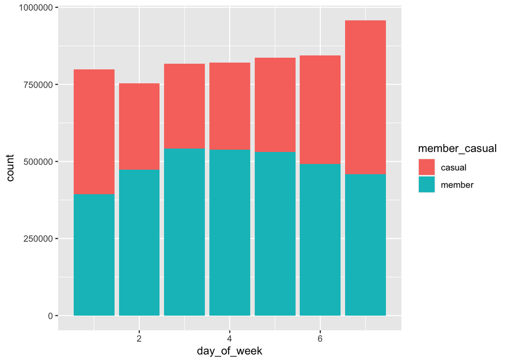

```r
ggplot(data = all_trips, aes(x=day_of_week, fill=member_casual)) +
  geom_bar(stat = "count")
```

```
## No summary function supplied, defaulting to `mean_se()`
```

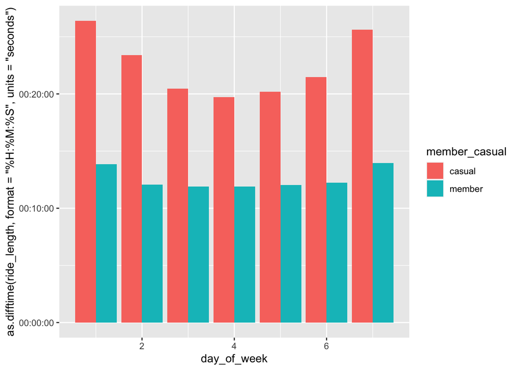

```r
ggplot(data = all_trips, aes(x=day_of_week, y=as.difftime(ride_length, format="%H:%M:%S", units="seconds"), fill=member_casual)) +
  geom_bar(position = "dodge", stat = "summary", fun.y = "mean")
```

#### 小結：

- 觀察普遍會員平均騎乘時間較casual用戶短，但每天趨勢差不多，推測可能為通勤或固定路線

## Wide period of time range

觀察時間週期較短的結果後，繼續往週期較長的範圍進行分析

```r
all_trips$date <- as.Date(all_trips$started_at)
all_trips$month <- format(as.Date(all_trips$date), "%m")
```

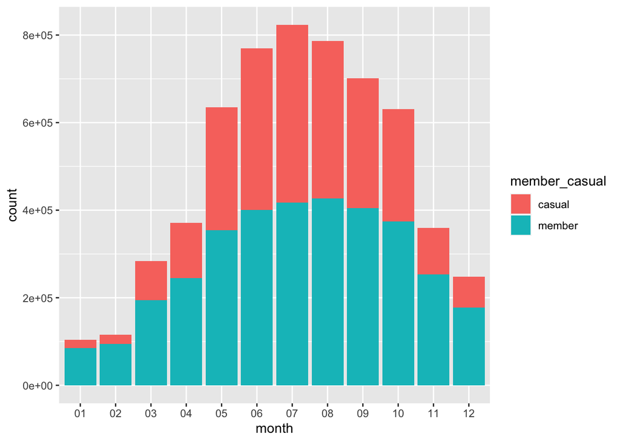

```r
ggplot(data = all_trips, aes(x=month, fill=member_casual)) +
  geom_bar(stat = "count")
```

```
## No summary function supplied, defaulting to `mean_se()`
```

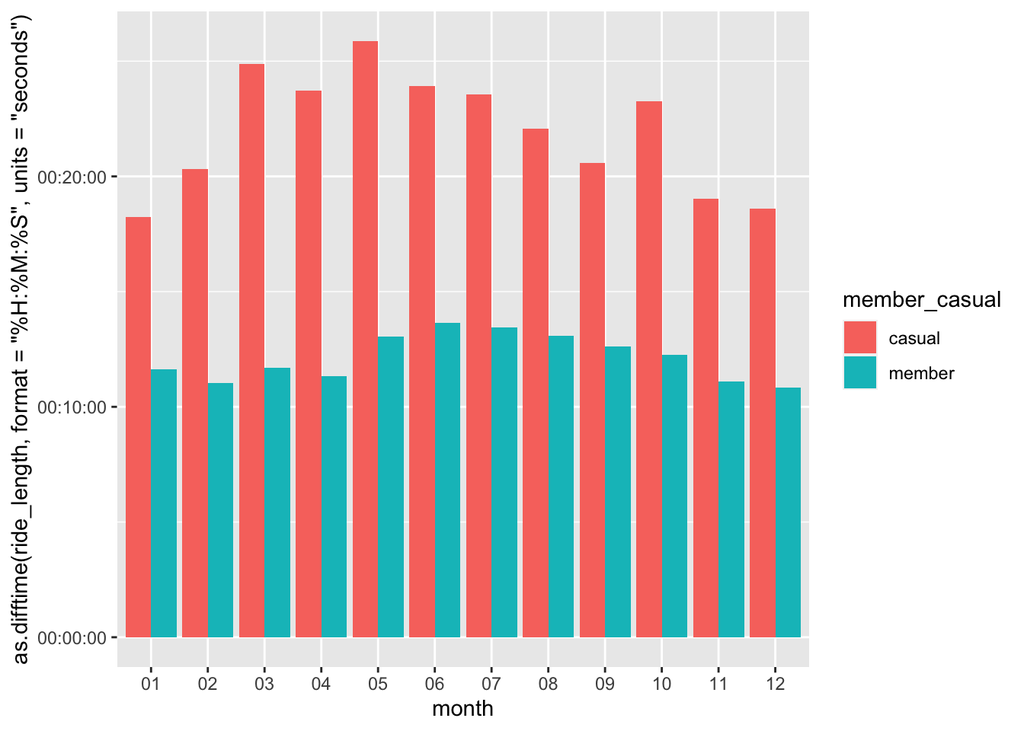

```r
ggplot(data = all_trips, aes(x=month, y=as.difftime(ride_length, format="%H:%M:%S", units="seconds"), fill=member_casual)) +
  geom_bar(position = "dodge", stat = "summary", fun.y = "mean")
```

#### 小結：

- 以月份進行比較發現，騎乘次數在每年5~10月為最多，此時約莫落在春末與夏季期間；平均騎乘時間則較無大的變動